```python
import pandas as pd
from textblob import TextBlob
import re
import tweepy
import keys
#import keys_twitter change name to keys.py
import matplotlib.pyplot as plt
import numpy as np

auth= tweepy.OAuthHandler(keys.consumer_key,keys.consumer_secret)
api= tweepy.API(auth,wait_on_rate_limit=True, wait_on_rate_limit_notify=True)
import math
```

[output not shown]

# Pardon My Take Twitter Usage

This project is done from my younger years of data science so I appologize for the poor organization, trust me I have learned that lesson. The project was for a presentation, so graphs were edited nicely next to eachother for comparison. This project utilized tweepy, the Twitter API which is no longer freely available and then used NLP analysis from a different workbook. This code is a few years old and I did not want to run into more intances with now banned tweepy so I have recently annotated it with notes from my presentation without reorganizaing it.

Thay being said lets look at the Number one Sports Podcast in the world and how their twitter behavior sets them apart. Talking about sports and pop culture, their twitter influence grew from daily sports bloggers to personalities of unfiltered nation wide influence within just a few years. This project took their most recent tweets(From 2021 back when tweepy was free) and did some digging to analyze their twitter use.

```python
#This uses text blob to get polarity of tweet after previous cleaning on seperate workbook

def clean_data(data,rows):
#making dict of mentioned for other purposes
  mentioned_dict={}

  for i in range(0,rows):
    if i%1000==0:
      print(i)

    tweet=data.loc[i,'tweet_text']
    mentioned=(data.loc[i,'accounts_mentioned'])
    mentioned_list=re.findall('\S+',str(mentioned),)
    name_list=[]



    #cannot set cell to a list
    name_str=''

    blue_check_count=0
    rando_count=0

    for name in mentioned_list:
      #gettng just the handle


      name=name.replace('[','')
      name=name.replace('.','')
      name=name.replace(']','')
      name=name.replace("'",'')
      name=name.replace(':','')
      name=name.replace(',','')
      name=name.replace(' ','')
      name=name.replace('’','')
      tweet=tweet.replace(name,'')
      tweet=tweet.replace('@','')

      #making mentioned into a list

      if name =='':
        data.loc[i,'accounts_mentioned']='none'
        mentioned_dict[i]=['none']

      else:


        name_list.append(name)
        name_str+=' '+name
        #makeing dict of each rows mentioned
      mentioned_dict[i]=name_list
      data.loc[i,'accounts_mentioned']=name_str

      tweet=str(tweet)
      link=(re.findall('http\S+',tweet))

      link=(str(link))
      link=link.replace('[','')
      link=link.replace(']','')
      link=link.replace("'",'')
      if link!='':
        data.loc[i,'used_link']=True
      else:
        data.loc[i,'used_link']=False
      #cleaning up the tweet to just give us the content of the meaning full words, taking out the links and meaningless symbols
      tweet=tweet.replace(link,'')
      tweet=tweet.replace('RT','')
      #turning acounts mentioned into a list


      blob=TextBlob(tweet)
      data.loc[i,"polarity"]=float(blob.sentiment.polarity)
  return(data,mentioned_dict)
```

```python
bigcat_data=pd.read_csv('/content/drive/MyDrive/pmt_twitter/bigcat.csv')
billy_data=pd.read_csv('/content/drive/MyDrive/pmt_twitter/billy_data.csv')
pft_data=pd.read_csv('/content/drive/MyDrive/pmt_twitter/pft_data.csv')
hank_data=pd.read_csv('/content/drive/MyDrive/pmt_twitter/hank_data.csv')
```

The next few lines are just creating the data sets how we needed and ensuring the work as expected.

```python
pft_data,list1=clean_data(pft_data,3200)
```

```
0
1000
2000
3000
```

```python
hank_data.head(30)
```

|  | Unnamed: 0 | name | handle | tweet_id | tweet_text | time | is_retweet | accounts_mentioned | is_about_gambling | about_pmt | used_link | polarity |
| --- | --- | --- | --- | --- | --- | --- | --- | --- | --- | --- | --- | --- |
| 0 | 0 | hank | hen_ease | 1384949539321393154 | Call of Duty such a joke lmao | 2021-04-21 19:17:55 | False |  | False | False | False | 0.300000 |
| 1 | 1 | hank | hen_ease | 1384931733674602500 | when can normal people play the new map? I'm s... | 2021-04-21 18:07:10 | False |  | False | False | True | -0.037879 |
| 2 | 2 | hank | hen_ease | 1384879149567852546 | RT @PardonMyMeme: Fuck the super league https:... | 2021-04-21 14:38:13 | True | PardonMyMeme | False | True | True | -0.033333 |
| 3 | 3 | hank | hen_ease | 1384878808369713155 | RT @PardonMyTake: RIPIP, Super League. \n\nYou... | 2021-04-21 14:36:52 | True | PardonMyTake | False | True | True | 0.566667 |
| 4 | 4 | hank | hen_ease | 1384679630666403840 | @TheBKBurger @BarstoolBigCat @PFTCommenter Che... | 2021-04-21 01:25:24 | False | TheBKBurger BarstoolBigCat PFTCommenter | False | False | False | -0.250000 |
| 5 | 5 | hank | hen_ease | 1384678291790049281 | RT @PardonMyTake: 👀👀👀 https://t.co/qN9hb58VvJ | 2021-04-21 01:20:05 | True | PardonMyTake | False | True | True | 0.000000 |
| 6 | 6 | hank | hen_ease | 1384672161189748738 | RT @SpinninBackfist: SHIZATT DA RIZATT: BACK T... | 2021-04-21 00:55:43 | True | SpinninBackfist roughnrowdy | False | False | False | 0.000000 |
| 7 | 7 | hank | hen_ease | 1384671891626016770 | @bigalmcc04 @StoolStreams lets see the tablecl... | 2021-04-21 00:54:39 | False | bigalmcc04 StoolStreams | False | False | False | 0.000000 |
| 8 | 8 | hank | hen_ease | 1384653872661155843 | RT @hen_ease: Great question! 🤟🏼😜😼All you have... | 2021-04-20 23:43:03 | True | hen_ease | False | False | True | 1.000000 |
| 9 | 9 | hank | hen_ease | 1384641039718301696 | @chimricholds700 @BarstoolYak @BarstoolBigCat ... | 2021-04-20 22:52:03 | False | chimricholds700 BarstoolYak BarstoolBigCat | False | False | False | 0.000000 |
| 10 | 10 | hank | hen_ease | 1384639348570787843 | @chimricholds700 @BarstoolYak what are you tal... | 2021-04-20 22:45:20 | False | chimricholds700 BarstoolYak | False | False | False | -0.125000 |
| 11 | 11 | hank | hen_ease | 1384596796605931521 | Happy holidays to all my fellow #MHOC cousins ... | 2021-04-20 19:56:15 | False |  | False | False | True | 0.800000 |
| 12 | 12 | hank | hen_ease | 1384589133050523650 | RT @PardonMyTake: (646) 762-6332\n\n🌳💨 420 edi... | 2021-04-20 19:25:48 | True | PardonMyTake | False | True | False | 0.125000 |
| 13 | 13 | hank | hen_ease | 1384577510952914945 | RT @spomedome: @hen_ease Some of the most ente... | 2021-04-20 18:39:37 | True | spomedome hen_ease | False | False | False | 0.500000 |
| 14 | 14 | hank | hen_ease | 1384574492182208527 | This may never end 😂😂😂😂 | 2021-04-20 18:27:37 | False |  | False | False | False | 0.000000 |
| 15 | 15 | hank | hen_ease | 1384573882930184197 | KB vs Nick for a chance at the Final Four!!! A... | 2021-04-20 18:25:12 | False |  | False | False | True | 0.000000 |
| 16 | 16 | hank | hen_ease | 1384568734493327364 | Feitelberg vs Keegs for a shot at the Final Fo... | 2021-04-20 18:04:45 | False | highnoonsunsips | False | False | True | 0.000000 |
| 17 | 17 | hank | hen_ease | 1384567395512168456 | Shark Tooth Don in the booth today https://t.c... | 2021-04-20 17:59:25 | False |  | False | False | True | 0.000000 |
| 18 | 18 | hank | hen_ease | 1384554959493079048 | RT @mags_mclaugh: Mids gang rise up | 2021-04-20 17:10:00 | True | mags_mclaugh | False | False | False | 0.000000 |
| 19 | 19 | hank | hen_ease | 1384543953530335244 | Great question! 🤟🏼😜😼All you have to do is down... | 2021-04-20 16:26:16 | False |  | False | False | True | 1.000000 |
| 20 | 20 | hank | hen_ease | 1384541524302700549 | His name is literally Johnny Hockey https://t.... | 2021-04-20 16:16:37 | False |  | False | False | True | 0.000000 |
| 21 | 21 | hank | hen_ease | 1384541093019140101 | My SONK picks are in. Where does this lose? ht... | 2021-04-20 16:14:54 | False |  | True | False | True | 0.000000 |
| 22 | 22 | hank | hen_ease | 1384535994645585923 | Holy hell https://t.co/vDLPD3xY4a | 2021-04-20 15:54:39 | False |  | False | False | True | 0.000000 |
| 23 | 23 | hank | hen_ease | 1384501327112425472 | 50 gs up for grabs don’t miss out! https://t.c... | 2021-04-20 13:36:53 | False |  | False | False | True | 0.000000 |
| 24 | 24 | hank | hen_ease | 1384501202826797056 | RT @TevoTeeven: 30 mins left to get in your pi... | 2021-04-20 13:36:24 | True | TevoTeeven hen_ease | False | False | False | -0.200000 |
| 25 | 25 | hank | hen_ease | 1384373096518402049 | RT @roughnrowdy: “This opponent for @DylanPost... | 2021-04-20 05:07:21 | True | roughnrowdy DylanPostl | False | False | False | 0.000000 |
| 26 | 26 | hank | hen_ease | 1384300376598319108 | RT @CelticsGRD: Celtics 7-1 since The Truth’s ... | 2021-04-20 00:18:23 | True | CelticsGRD | False | False | True | 0.136364 |
| 27 | 27 | hank | hen_ease | 1384300266799857667 | If I was a kid I would be buying a Jabari Park... | 2021-04-20 00:17:57 | False |  | False | False | False | 0.000000 |
| 28 | 28 | hank | hen_ease | 1384296601699590149 | @DanaBeers_ I feel the same about dropping pod... | 2021-04-20 00:03:23 | False | DanaBeers_ | False | False | False | 0.000000 |
| 29 | 29 | hank | hen_ease | 1384208824844787712 | RT @DUDEwipes: @hen_ease We are definitely Tea... | 2021-04-19 18:14:35 | True | DUDEwipes hen_ease | False | False | False | 0.000000 |

```python
(billy_data,billy_mentioned)=clean_data(billy_data,3221)
```

```
0
1000
2000
3000
```

```python
(bigcat_data,bigcat_mentioned)=clean_data(bigcat_data,3247)
```

```
0
1000
2000
3000
```

```python
bigcat_data['tweet_text']
```

```
0       Edelman describing the best eyes in the huddle...
1       RT @PardonMyTake: Big things coming for our fr...
2       RT @Edelman11: … Annnnd action! 🎥 @_coastpro i...
3                                  #SaveStanfordWrestling
4       YAK starts now. Packed house. Caleb is back. L...
                              ...
3242                            @BWalkerSEC @kbnoswag Sup
3243    RT @kbnoswag: @BarstoolBigCat it’s a jungle ou...
3244    @kbnoswag Can’t wait for tomorrow. Will be gre...
3245    RT @barstoolchicago: Have to love Jay making t...
3246                          QB1 https://t.co/PvBDMtrevG
Name: tweet_text, Length: 3247, dtype: object
```

```python
(pft_data,pft_mentioned)=clean_data(pft_data,3221)
```

```
0
1000
2000
3000
```

```python
(hank_data,hank_mentioned)=clean_data(hank_data,3225)
```

```
0
1000
2000
3000
```

```python
billy_mentioned_list=list(billy_mentioned.values())
pft_mentioned_list=list(pft_mentioned.values())
bigcat_mentioned_list=list(bigcat_mentioned.values())
hank_mentioned_list=list(hank_mentioned.values())
all_mentioned=bigcat_mentioned_list+ billy_mentioned_list+pft_mentioned_list+hank_mentioned_list+billy_mentioned_list
```

```python
'kfcbarstool' in hank_mentioned_list
```

```
False
```

Now that I have everything loaded in. We can begin analysis. 'kfcbarstool' is a personality that had a similar trajectory as the podcast. 'kfcbarstool' at the time was beefing with hank so I wanted to see if there was any interactions. Unfortunatley not. We will move onto getting all users mentioned into a list.

```python
def flatten_list(_2d_list):
    flat_list = []
    # Iterate through the outer list
    for element in _2d_list:
        if type(element) is list:
            # If the element is of type list, iterate through the sublist
            for item in element:
                flat_list.append(item)
        else:
            flat_list.append(element)
    return flat_list
```

```python
#making unique list of all users mentioned
all_mentioned_flat=flatten_list(all_mentioned)
mentioned_unique = []
for x in all_mentioned_flat:
    if x not in mentioned_unique:
        mentioned_unique.append(x)
len(mentioned_unique)
```

```
3444
```

The 4 podcast hosts we will look at have mentioned 3,444 unique users. We will do some quick data set up to define if these users are celebrities.

```python
#made dict of how many times a user was mentioned
#user: times mentioned
from collections import Counter
counted_mentions=Counter(all_mentioned_flat)
mentioned_alot=[]
#making a list of all the users mentioned more than 10 times assuming account may be similar
for user in mentioned_unique:
  if counted_mentions[user]>5:
    mentioned_alot.append(user)
```

```python
#getting list of look up user mentioned
all_mentioned_accounts=[]
for i in range(math.ceil(len(mentioned_unique)/100)):
  current_name_list=mentioned_unique[i*100:i*100+100]
  all_mentioned_accounts.append(api.lookup_users(screen_names=current_name_list))
  #all accounts data!1
all_mentioned_accounts_list = [item for sublist in all_mentioned_accounts for item in sublist]
```

```python
mentioned_is_celeb={}
#defining twitter celeb>50000 followers
#some people dont want to be verified
for account in all_mentioned_accounts_list:
  if account.followers_count>50000:
    mentioned_is_celeb[account.screen_name]=True
  else:
    mentioned_is_celeb[account.screen_name]=False
```

This defines how we want to make pie plots to see the types of accounts the podcats hosts engage with.

```python
def mentioned_pie(mentioned_list,data):
  no_mentions=0
  errors=0
  celeb_mentions=0
  rando_mentions=0
  #creating is rando and is celeb columns
  for i in range(0,len(data)):
    #may need to change
    if data.loc[i,'accounts_mentioned']=='[]':
      no_mentions+=1
    if data.loc[i,'accounts_mentioned']=='':
      no_mentions+=1
      #mentioned list is not flattened
  list1=flatten_list(mentioned_list)
  for name in list1:
      #taking their names out, could consider them tweeting a friend, or a celeb so just going to make it count as 0
      if str(name) !='hen_ease' or 'BarstoolBigCat' or 'Billyhottakes' or 'PFTCommenter':
        try:
          if mentioned_is_celeb[name]== True:
            celeb_mentions+=1
          else:
            rando_mentions+=1
        except:
          errors+=1
          #I have checked these erros are from account that have snese been deactivated or @ wrong in tweet, all data is correct
  labels='random account mentioned', '"twitter celeb" mentioned'
  sizes=rando_mentions,celeb_mentions
  fig1, ax1 = plt.subplots()
  ax1.pie(sizes,labels=labels,shadow=True ,startangle=90, autopct='%1.0f%%' )
  ax1.axis('equal')
  plt.show()
  labels='engaging other accounts', 'tweeting to tweet'
  sizes=rando_mentions+celeb_mentions+errors, no_mentions
  fig1, ax1 = plt.subplots()
  ax1.pie(sizes,labels=labels,shadow=True ,startangle=90, autopct='%1.0f%%' )
  ax1.axis('equal')
  plt.show()
  print(errors)
```

This is a df of the accounts The Pardon My Take crew most often engage with. This is used for comparison of their twitter behaviors. It is assumed that these counts are at least in somewhat similar worlds and buisnesses of Pardon My Take. For example here, a few accounts mentioned are different podcast hosts in the sports world.

```python
compare_data
```

|  | Unnamed: 0 | name | handle | tweet_id | tweet_text | time | is_retweet | accounts_mentioned | is_about_gambling | about_pmt | used_link | polarity |
| --- | --- | --- | --- | --- | --- | --- | --- | --- | --- | --- | --- | --- |
| 0 | 0 | PMTsportsbiz | PMTsportsbiz | 1384948536886939648 | RT @stoolbenchmob: What are your favorite “coa... | 2021-04-21 19:13:56 | True | stoolbenchmob | False | False | False | 0.500000 |
| 1 | 1 | PMTsportsbiz | PMTsportsbiz | 1384697640177315842 | RT @BarstoolBigCat: Only mistake was Rico not ... | 2021-04-21 02:36:58 | True | BarstoolBigCat | False | False | False | 0.033333 |
| 2 | 2 | PMTsportsbiz | PMTsportsbiz | 1384697055243821059 | RT @OwenRoeder: Great year 1 in the books @sto... | 2021-04-21 02:34:39 | True | OwenRoeder stoolbenchmob | False | False | False | 0.800000 |
| 3 | 3 | PMTsportsbiz | PMTsportsbiz | 1384685524250681347 | RT @BarstoolBigCat: Great dinner at Lugers. Th... | 2021-04-21 01:48:49 | True | BarstoolBigCat Return_Of_RB | False | False | False | 0.800000 |
| 4 | 4 | PMTsportsbiz | PMTsportsbiz | 1384541590434324492 | @hen_ease #SONK https://t.co/5bfiTpV1Hf | 2021-04-20 16:16:53 | False | hen_ease | False | False | True | 0.000000 |
| ... | ... | ... | ... | ... | ... | ... | ... | ... | ... | ... | ... | ... |
| 77296 | 3243 | diannaESPN | diannaESPN | 1302400247843508225 | Jadeveon Clowney has told Titans officials he ... | 2020-09-06 00:16:31 | False |  | False | False | True | 0.000000 |
| 77297 | 3244 | diannaESPN | diannaESPN | 1302377303268352002 | Jadeveon Clowney is expected to sign with the ... | 2020-09-05 22:45:20 | False |  | False | False | True | -0.100000 |
| 77298 | 3245 | diannaESPN | diannaESPN | 1302337372672143364 | w o w https://t.co/0MYhwBxtTa | 2020-09-05 20:06:40 | False |  | False | False | True | 0.000000 |
| 77299 | 3246 | diannaESPN | diannaESPN | 1302254547595911168 | RT @AdamSchefter: Deshaun Watson’s contract is... | 2020-09-05 14:37:33 | True | AdamSchefter | False | False | False | 0.068750 |
| 77300 | 3247 | diannaESPN | diannaESPN | 1302254446794113027 | RT @McClain_on_NFL: Texans have agreed on a 4-... | 2020-09-05 14:37:09 | True | McClain_on_NFL | False | False | False | 0.000000 |

77301 rows × 12 columns

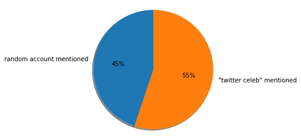

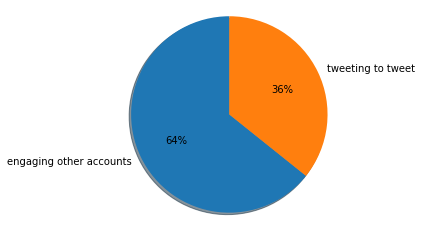

```
88
```

```python
mentioned_pie(bigcat_mentioned_list,bigcat_data)
```

This is Bigcat. For a "celeberity" he is notorious for engaging with celebreities and fans alike. Our analysis shows 64% of the time he takes to twitter he is engaging with other acocunts. 36% of the time is he just tweeting his thoughts or opinions for the world to hear. Then for a celebrity he has made a reputation not carrying who engages with, yelling at celebrities at regular accounts alike. This is backed up by nearly a 50/50 spilt of the type of people he engages with. For an account with over a million followers Bigcat will yell at anyone on twitter.

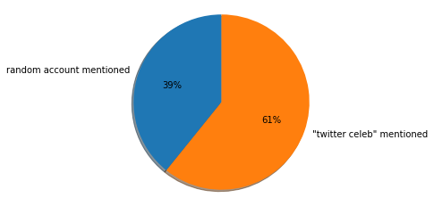

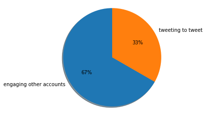

```
136
```

```python
mentioned_pie(pft_mentioned_list,pft_data)
```

This is PFT. Once again he has made a name on twitter engaging with people. PFT is notorious for trolling celebrities. He is not scared to tweet at athletes or make jokes about celebrities. With over a million followers he still acts like he is running a twitter burner account but now he has a bit of status. PFT treats celebrities like he does anyone, and engages with them even more than Bigcat.

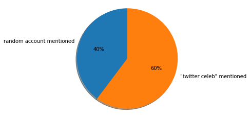

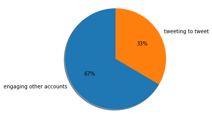

```
118
```

```python
mentioned_pie(billy_mentioned_list,billy_data)
```

The is the Intern Billy football. Much like his bosses he routinely engages with twitter accounts. His bosses joke how he acts like a celebrity on twitter "tweeting just to tweet", however he could show him this data to despute it. His twitte presence looks much like his two bosses PFT and Bigcat. Contrary to popula belief maybe Billy has learned a thing or two being on the podcast.

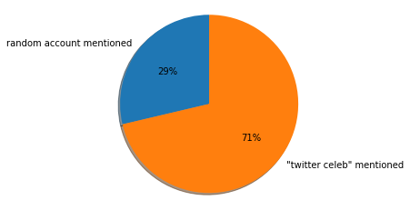

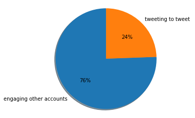

```
147
```

```python
mentioned_pie(hank_mentioned_list,hank_data)
```

Hank is the producer. He is the behind the scense guy, while active on twitter not nearly as much. His twitter presence was not necarsily why Pardon My Take got big. It is interesting to see his twitter habits differe from the podcast hosts. It appears he knows he is not a celebrity, he doesn't just tweet to tweet nearly as much. But when he does tweet he is the most common to engage with a celebrity. This makes sense as he tries to represent the podcast, support the people who come on the show, often playing the polotics game with getting guests and making celebrity connections.

```python
def tweets_emotional(data):
  emotional=0
  nuetral=0
  for i in data['polarity']:
    #classify emotional as anything more than .1
    if (int(i))!=0:
      emotional+=1
    else:
      nuetral+=1

  labels='emotional tweets', 'not emotional tweets'
  sizes=emotional,nuetral
  fig1, ax1 = plt.subplots()
  ax1.pie(sizes,labels=labels,shadow=True ,startangle=90, autopct='%1.0f%%')
  ax1.axis('equal')
  plt.show()
```

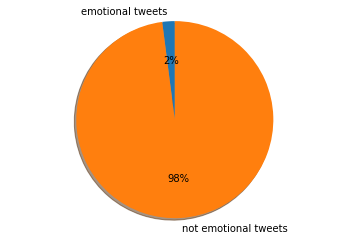

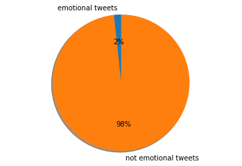

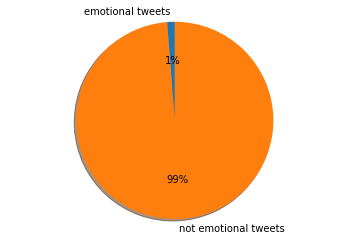

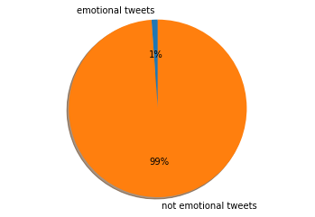

```python
tweets_emotional(hank_data)
tweets_emotional(avg_data)
tweets_emotional(billy_data)
tweets_emotional(pft_data)
```

Using NLP I wanted to see if anyone is extra emotional. Unfortunatley the models that I had back in 2021 were not able to catch much severe emotion so this was a bit of a dead end.

```python
def about_gambling(data):
  about_gambling=0
  #to give a number for a bar graph

  for i in data['is_about_gambling']:
    if i==True:
      about_gambling+=1
  return(about_gambling)
```

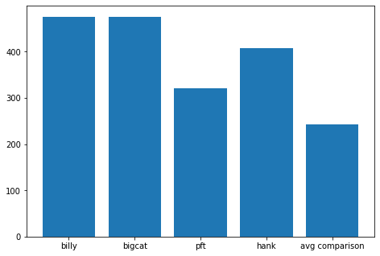

```python
billy=about_gambling(bigcat_data)
bigcat=about_gambling(bigcat_data)
pft=about_gambling(pft_data)
hank=about_gambling(hank_data)
avg=about_gambling(avg_data)/10
fig = plt.figure()
ax = fig.add_axes([0,0,1,1])
langs = ['billy', 'bigcat', 'pft', 'hank', 'avg comparison']
students = [billy,bigcat,pft,hank,avg]
ax.bar(langs,students)
plt.show()
```

```python
def about_pmt(data):
  #mentioned pardon
  count=0
  #to give a number for a bar graph

  for i in data['about_pmt']:
    if i==True:
      count+=1
  return(count)
```

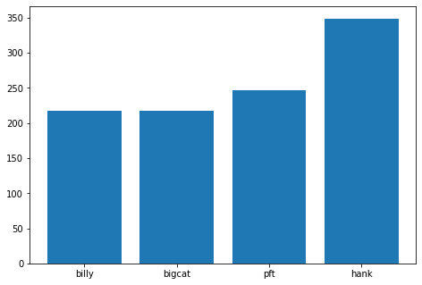

```python
billy=about_pmt(bigcat_data)
bigcat=about_pmt(bigcat_data)
pft=about_pmt(pft_data)
hank=about_pmt(hank_data)

fig = plt.figure()
ax = fig.add_axes([0,0,1,1])
langs = ['billy', 'bigcat', 'pft', 'hank']
students = [billy,bigcat,pft,hank]
ax.bar(langs,students)
plt.show()
```

```python
def used_link(data):
  #mentioned pardon
  count=0
  #to give a number for a bar graph

  for i in data['used_link']:
    if i==True:
      count+=1
  return(count)
```

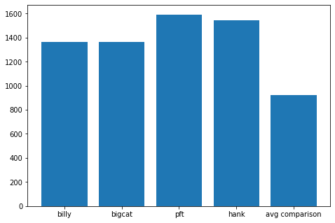

```python
billy=used_link(bigcat_data)
bigcat=used_link(bigcat_data)
pft=used_link(pft_data)
hank=used_link(hank_data)
avg=used_link(avg_data)/10

fig = plt.figure()
ax = fig.add_axes([0,0,1,1])
langs = ['billy', 'bigcat', 'pft', 'hank','avg comparison']
students = [billy,bigcat,pft,hank,avg]
ax.bar(langs,students)
plt.show()
```

```python
#creating a dict to search screen_name: lookup data
mentioned_dict={}
for account in all_mentioned_accounts_list:
  mentioned_dict[account.screen_name]=account
```

```python
accounts_to_test=[]
for name in mentioned_alot:
  try:
    account=mentioned_dict[name]
    #finding accounts with similar "influence"
    if 200000<account.followers_count<1300000:
     accounts_to_test.append(name)
  except:
    print(name)
```

```
…
Billyhottakes?
pardonmytake
RoneCatMgmt
Karry0078
ZeeEmmYT
CherryDank
WayneJetskii
JoelNorris777
astroscrazy5
stoolstreams
DanaB_Number3
```

```python
avg_data=compare_data[compare_data['name']!='BarstoolBigCat']
avg_data=avg_data[avg_data['name']!='KFCBarstool']
avg_data=avg_data[avg_data['name']!='hen_ease']
avg_data.to_csv('avg_data')
```

# Getting people to compare

This is where the account to compare too are from. Most of the accounts are podcasts hosts at Barstool Sports where Pardon My Take is. These will give us a better idea to compare. This project was done for a presentation, that is why the graphs may be in a different spot, but they were formated nicely and put with the similar graphs.

```python
for name in accounts_to_test:
  #taking all other barstool people out (where these people work)
  account=mentioned_dict[name]
  test=re.findall('barstool',name.lower())
  if test==[]:
    bio=str(account.description.lower())

    test2=re.findall('barstool',bio)
    if test2!=[]:
      accounts_to_test.remove(name)

  else:
    accounts_to_test.remove(name)
accounts_to_test.remove('hen_ease')
accounts_to_test.remove('KFCBarstool')
```

```python
#same function as before
def get_data(name,handle,data_set):
    list_of_all=[]
    tweets=tweepy.Cursor(api.user_timeline, screen_name=handle, count=200).items(3500)
    for tweet in tweets:
        #tweet id
        tweet_id=tweet.id
        #twet text
        tweet_text= tweet.text
        #time
        time=tweet.created_at
        rt=re.findall('RT\s',tweet_text)
        #is a retweet
        if rt !=[]:
            is_rt=True
        else:
            is_rt=False
            #gambling words used
        gambling_words=re.findall('bet|gamble|gambling|over|under|spread|cover|odds|win|lose|money|parlay|line', tweet_text.lower())
        #about gambling
        if gambling_words !=[]:
            about_gambling=True
        else:
            about_gambling=False
        mention=re.findall('\@(\S+)',tweet_text)
        if mention !=[]:
            if name in mention:
                mention.remove(name)
            #accounts_mentioned
        accounts_mentioned=mention
        about=re.findall('pmt|pardon',tweet_text.lower())
        if about!=[]:
            related_to_pmt=True
        else:
            related_to_pmt=False
        list_for_data=name,handle,tweet_id,tweet_text,time,is_rt,accounts_mentioned,about_gambling,related_to_pmt
        list_of_all.append(list_for_data)
        new_data=pd.DataFrame(list_of_all, columns = ['name','handle','tweet_id','tweet_text','time','is_retweet','accounts_mentioned','is_about_gambling','about_pmt'])


    return(new_data)



        #'name','handle','tweet_id','tweet_text','time','is_retweet','accounts_mentioned','is_about_gambling','about_pmt'])
```

```python
compare_data=pd.DataFrame(columns = ['name','handle','tweet_id','tweet_text','time','is_retweet','accounts_mentioned','is_about_gambling','about_pmt'])
for handle in accounts_to_test[0:10]:
  compare_data=compare_data.append(get_data(handle,handle,compare_data))
```

```python
compare_mention_list=list(compare_mention.values())
compare_mention_list=flatten_list(compare_mention_list)
avg_data=pd.read_csv('avg_data')
len(compare_mention_list)
```

```
23665
```

```python
(avg_data, compare_mention)=clean_data(avg_data,22491)
```

```
0
1000
2000
3000
4000
5000
6000
7000
8000
9000
10000
11000
12000
13000
14000
15000
16000
17000
18000
19000
20000
21000
22000
```

```python
avg_data
```

|  | Unnamed: 0 | name | handle | tweet_id | tweet_text | time | is_retweet | accounts_mentioned | is_about_gambling | about_pmt |
| --- | --- | --- | --- | --- | --- | --- | --- | --- | --- | --- |
| 0 | 0 | CashApp | CashApp | 1384649319370919937 | The #CashAppPayDay $100K Uno tournament is sta... | 2021-04-20 23:24:57 | False | [] | False | False |
| 1 | 1 | CashApp | CashApp | 1384616387331575818 | An extra special Cash App Trivia game giving a... | 2021-04-20 21:14:06 | False | [] | False | False |
| 2 | 2 | CashApp | CashApp | 1384604199648862208 | We’re celebrating the @100Thieves Cash Card wi... | 2021-04-20 20:25:40 | False | ['100Thieves'] | False | False |
| 3 | 3 | CashApp | CashApp | 1384601992463482880 | Introducing the exclusive @100Thieves Cash Car... | 2021-04-20 20:16:54 | False | ['100Thieves'] | False | False |
| 4 | 4 | CashApp | CashApp | 1384250702642311172 | @100Thieves @AustinOnTwitter 💵 | 2021-04-19 21:01:00 | False | ['100Thieves', 'AustinOnTwitter'] | False | False |
| ... | ... | ... | ... | ... | ... | ... | ... | ... | ... | ... |
| 22487 | 3234 | ryanwhitney6 | ryanwhitney6 | 857707931223117824 | Trash bucket move if I've ever seen one https:... | 2017-04-27 21:28:00 | False | [] | False | False |
| 22488 | 3235 | ryanwhitney6 | ryanwhitney6 | 857441275309588480 | @mike_p_johnson Can't think of anyone in histo... | 2017-04-27 03:48:25 | False | ['mike_p_johnson'] | False | False |
| 22489 | 3236 | ryanwhitney6 | ryanwhitney6 | 857433796488114176 | @RearAdBsBlog Veteran | 2017-04-27 03:18:42 | False | ['RearAdBsBlog'] | False | False |
| 22490 | 3237 | ryanwhitney6 | ryanwhitney6 | 857431656134823936 | That ain't gonna happen. That money is gonezo ... | 2017-04-27 03:10:11 | False | [] | True | False |
| 22491 | 3238 | ryanwhitney6 | ryanwhitney6 | 857353408688291843 | @bfoley0912 @MarkMaddenX Madden my boy foley a... | 2017-04-26 21:59:16 | False | ['bfoley0912', 'MarkMaddenX'] | False | False |

22492 rows × 10 columns

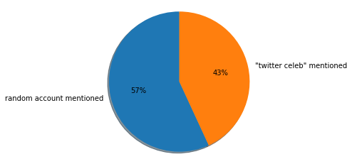

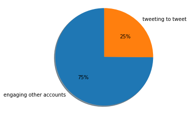

```
2043
```

```python
mentioned_pie(compare_mention_list,avg_data)
```

This is the end of the presentation. Below is a bit about how the Pardon My Take peers were found to create a "average" for comparison.

```python
print('dict')
print(len(mentioned_is_celeb))
#getting list of all unique mentions
compare_mentioned_unique=[]
for name in compare_mention_list:
    if name not in mentioned_unique:
      compare_mentioned_unique.append(name)
print(len(compare_mentioned_unique))
#will add not mentioned to current account list
#getting accounts
compare_to_add_accounts=[]
for i in range(math.ceil(len(compare_mentioned_unique)/100)):
  current_name_list=compare_mentioned_unique[i*100:i*100+100]
  compare_to_add_accounts.append(api.lookup_users(screen_names=current_name_list))
all_mentioned_to_add_list = [item for sublist in compare_to_add_accounts for item in sublist]
print(len(all_mentioned_to_add_list))
```

```
dict
3107
16484
10005
```

```python
(avg_data,avg_metntioned)=clean_data(avg_data,22492)
```

```
0
1000
2000
3000
4000
5000
6000
7000
8000
9000
10000
11000
12000
13000
14000
15000
16000
17000
18000
19000
20000
21000
22000
```

```python
compare_data=compare_data.head(77301)
```

```python
compare_data.to_csv('compare_cleaned_data')
```